# R Notebook

Maggie Seida

CHapter 7 Notes and Exercises

exploratory data analysis, or EDA for short

```r
library(tidyverse)
```

key to asking quality questions is to generate a large quantity of questions Ex. of question types:  
What type of variation occurs within my variables?  
What type of covariation occurs between my variables?

**Variation** is the tendency of the values of a variable to change from measurement to measurement.

A variable is **categorical** if it can only take one of a small set of values.  
- To examine the distribution of a categorical variable, use a bar chart

A variable is **continuous** if it can take any of an infinite set of ordered values. Numbers and date-times are two examples of continuous variables.  
- To examine the distribution of a continuous variable, use a histogram

To use many histograms in same plot… geom_freqpoly() instead of geom_histogram().  
- uses lines

**7.3.4 Exercises**

```r
summary(select(diamonds, x, y, z))
```

```
       x                y                z
 Min.   : 0.000   Min.   : 0.000   Min.   : 0.000
 1st Qu.: 4.710   1st Qu.: 4.720   1st Qu.: 2.910
 Median : 5.700   Median : 5.710   Median : 3.530
 Mean   : 5.731   Mean   : 5.735   Mean   : 3.539
 3rd Qu.: 6.540   3rd Qu.: 6.540   3rd Qu.: 4.040
 Max.   :10.740   Max.   :58.900   Max.   :31.800
```

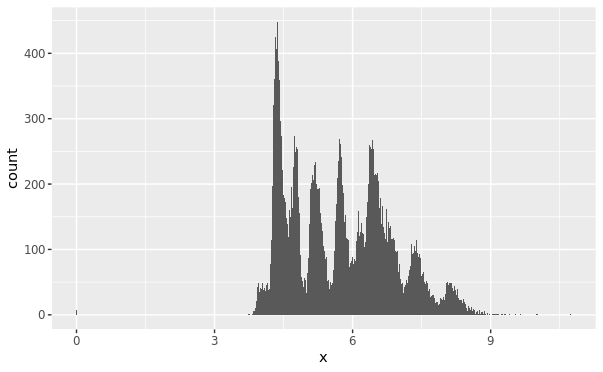

```r
ggplot(diamonds) +
  geom_histogram(mapping = aes(x = x), binwidth = 0.01) #to look at x variable
```

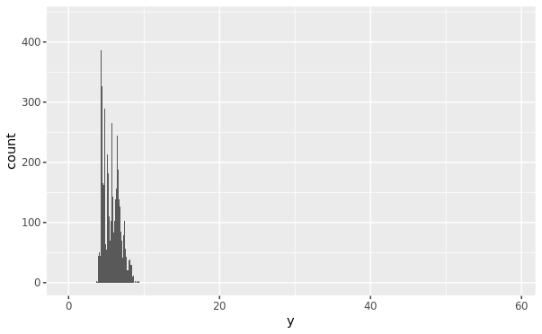

```r
ggplot(diamonds) +
  geom_histogram(mapping = aes(x = y), binwidth = 0.01) #to look at y variable
```

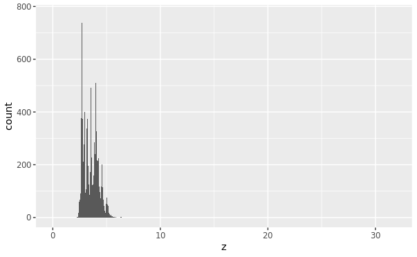

```r
ggplot(diamonds) +
  geom_histogram(mapping = aes(x = z), binwidth = 0.01) #to look at z variable
```

```r
head(diamonds)
```

| carat | cut | color | clarity | depth | table | price | x | y | z |
| --- | --- | --- | --- | --- | --- | --- | --- | --- | --- |
| 0.23 | Ideal | E | SI2 | 61.5 | 55 | 326 | 3.95 | 3.98 | 2.43 |
| 0.21 | Premium | E | SI1 | 59.8 | 61 | 326 | 3.89 | 3.84 | 2.31 |
| 0.23 | Good | E | VS1 | 56.9 | 65 | 327 | 4.05 | 4.07 | 2.31 |
| 0.29 | Premium | I | VS2 | 62.4 | 58 | 334 | 4.20 | 4.23 | 2.63 |
| 0.31 | Good | J | SI2 | 63.3 | 58 | 335 | 4.34 | 4.35 | 2.75 |
| 0.24 | Very Good | J | VVS2 | 62.8 | 57 | 336 | 3.94 | 3.96 | 2.48 |

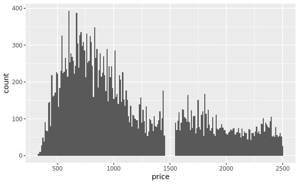

```r
ggplot(filter(diamonds, price < 2500), aes(x = price)) +
  geom_histogram(binwidth = 10, center = 0)
```

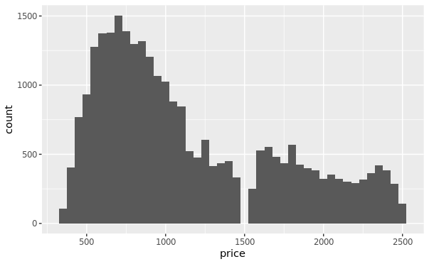

```r
ggplot(filter(diamonds, price < 2500), aes(x = price)) +
  geom_histogram(binwidth = 50, center = 0)
```

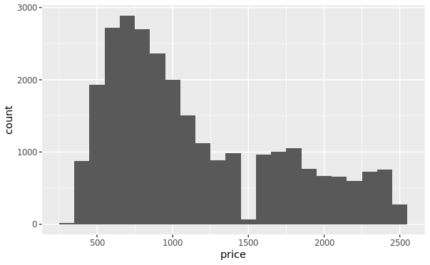

```r
ggplot(filter(diamonds, price < 2500), aes(x = price)) +
  geom_histogram(binwidth = 100, center = 0)
```

```r
diamonds %>%
  filter(carat >= 0.99, carat <= 1) %>%
  count(carat)
```

| carat | n |
| --- | --- |
| 0.99 | 23 |
| 1.00 | 1558 |

Only 23 diamonds are 0.99 carat whereas 1558 diamonds are 1.00 carat.

**7.4**

If you have unusual points in your data you can remove whole row (not recommended bc some values may be valid) or just replace the unusual values with missing values.  
ex. diamonds2 <- diamonds %>% mutate(y = ifelse(y < 3 | y > 20, NA, y))  
use the ifelse() fcn to do this

ggplot will automatically removed missing values and will show warning message. To suppress that warning, set na.rm = TRUE:

Or you can make missing values into new variable with is.na().

7.4 Exercises In histogram, missing values are removed and ggplot shows warning message but just graphs without the variables In boxplot, missing values act like another category. na.rm = TRUE removes NA values and doesn’t include them in the mean and the sum

**7.5** covariation describes the behavior between variables  
ggplot(data = mpg) + geom_boxplot(mapping = aes(x = reorder(class, hwy, FUN = median), y = hwy)) + coord_flip()  
coord_flip() flips the boxplot horizontally

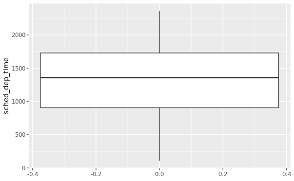

```r
nycflights13::flights %>%
  ggplot() +
  geom_boxplot(mapping = aes(y = sched_dep_time))
```

To visualise the covariation between categorical variables, you’ll need to count the number of observations for each combination.  
geom_count():

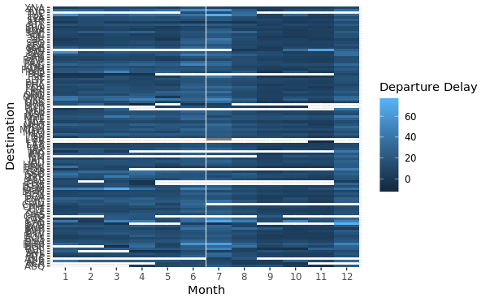

```r
nycflights13::flights %>%
  group_by(month, dest) %>%
  summarise(dep_delay = mean(dep_delay, na.rm = TRUE)) %>%
  ggplot(aes(x = factor(month), y = dest, fill = dep_delay)) +
  geom_tile() +
  labs(x = "Month", y = "Destination", fill = "Departure Delay")
```

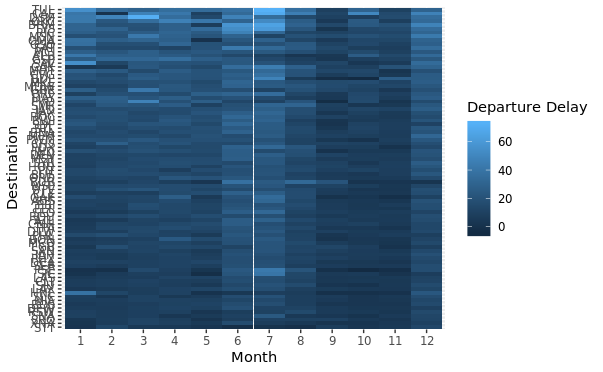

```r
nycflights13::flights %>%
  group_by(month, dest) %>%
  summarise(dep_delay = mean(dep_delay, na.rm = TRUE)) %>%
  group_by(dest) %>%
  filter(n() == 12) %>%
  ungroup() %>%
  mutate(dest = reorder(dest, dep_delay)) %>%
  ggplot(aes(x = factor(month), y = dest, fill = dep_delay)) +
  geom_tile() +
  labs(x = "Month", y = "Destination", fill = "Departure Delay")
```

Draw a visualization btwn two continuous variables with a scatterplot geom_point()

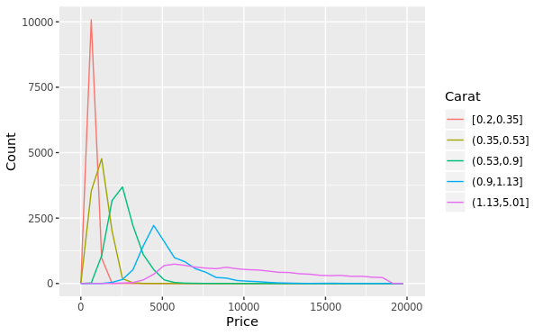

```r
ggplot(
  data = diamonds,
  mapping = aes(color = cut_number(carat, 5), x = price)
) +
  geom_freqpoly() +
  labs(x = "Price", y = "Count", color = "Carat")
```

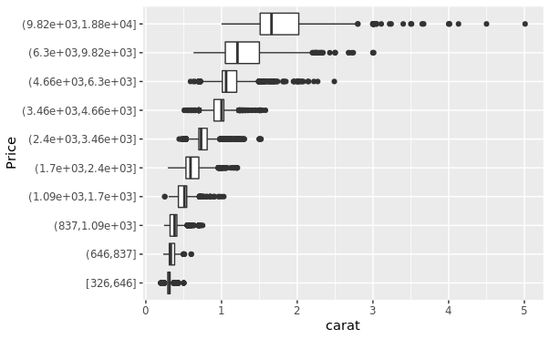

```r
ggplot(diamonds, aes(x = cut_number(price, 10), y = carat)) +
  geom_boxplot() +
  coord_flip() +
  xlab("Price")
```

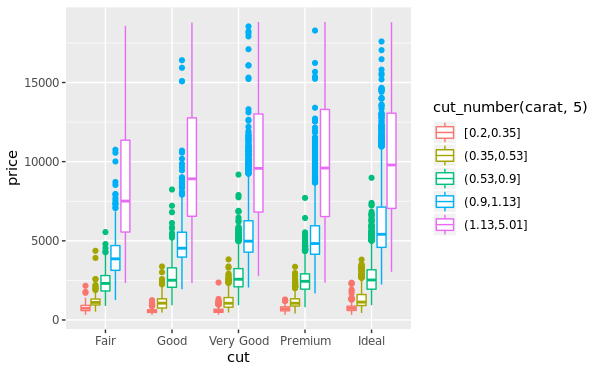

```r
ggplot(diamonds, aes(color = cut_number(carat, 5), y = price, x = cut)) +
  geom_boxplot()
```